# Sistemas Dinâmico e Álgebra Linear

Daniel Coutinho

2018-10-31

Este é mais um post na linha de “como eu gostaria de ter sido apresentado à”. O tema de hoje é Algebra Linear. Este é um dos cursos que muitos alunos acham excessivamente abstrato, e portanto, inútil. De fato, eu tive um pouco desta sensação quando eu fiz o curso. A verdade está muito distante disso.

Suponha que nós temos um sistema de equações (lineares), e este sistema evolui ao longo do tempo. Ele pode ser descrito como $x_{t+1} = Ax_{t}$, onde $x_t$ é o vetor de interesse e $A$ é a matriz que governa como as variáveis se relacionam. Também precisamos de uma condição inicial $x_0$. Veja que calcular o valor do sistema no tempo $T$ é equivalente a fazer $A^{T} x_0$, onde $A^{T} = A \times A \times A$, $T$ vezes.

Já encontramos uma situação similar a essa em um post anterior, no qual eu falei de Autoregressão vetorial (VAR). Lá, estavamos interessados em recuperar a matriz A, e o nosso sistema tinha um choque aleatório $\epsilon_t$. Nosso interesse hoje é saber quando o sistema é estável. Ser estável quer dizer que o sistema não explode, como é o caso do exemplo abaixo:

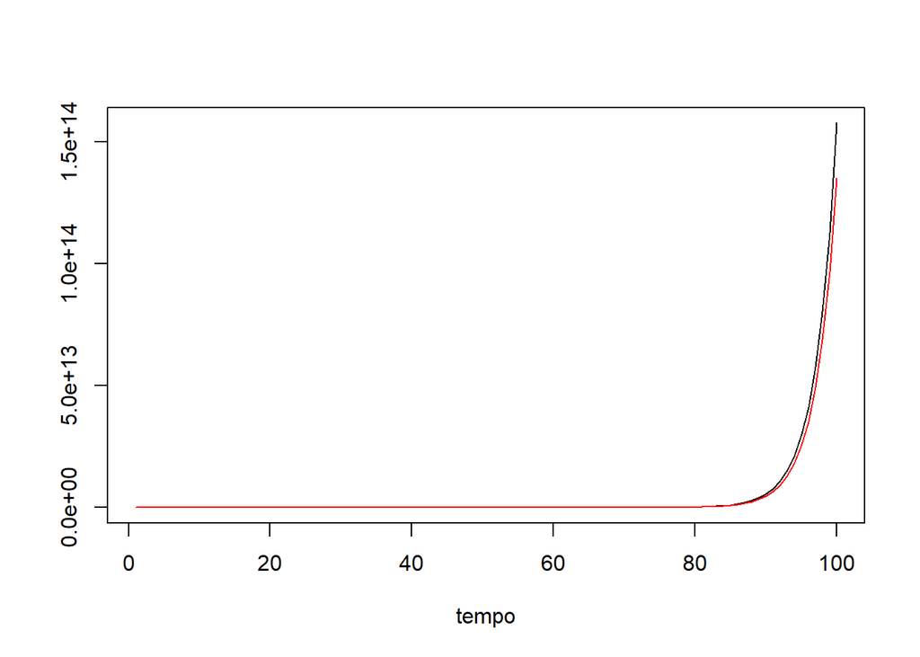

```r
A <- rbind(c(0.8,0.7),c(0.6,0.7))
x <- matrix(0,ncol = 2, nrow = 100)
x[1,] <- c(1,0)
for(i in 1:99){
  x[i+1,] <- A%*%x[i,]
}
plot(x[,1], type="l", ylab = " ", xlab = "tempo")
lines(x[,2], type = "l", col = 2)
```

Um sistema não explosivo vai voltar a um estado de “repouso” do sistema. Veja que isso soa familiar: nós esperamos que a economia saia do equilíbrio mas volte a ele (ou a um novo equilíbrio). Como podemos saber se um sistema dinâmico linear é explosivo ou não?

A resposta são os autovalores da matriz $A$ - na verdade, apenas o maior deles (em módulo). A ideia aqui é que a matriz $A$ possa ser decomposta em seus autovalores e autovetores. Seja $\Lambda$ uma matriz que tem na diagonal os autovalores e fora dela zero; e $P$ uma matriz que tem os autovetores. Então, $A = P\Lambda{}P^{-1}$. Mais ainda, $A^j = P\Lambda^jP^{-1}$, onde $\Lambda^j$ é equivalente a elevar cada entrada da diagonal a $j$. Logo, toda a dinâmica do sistema é governada pelos autovalores!

Para provar o ponto, eis os autovalores da matriz A do exemplo anterior:

```r
eigen(A)
```

```
## eigen() decomposition
## $values
## [1] 1.4 0.1
##
## $vectors
##           [,1]       [,2]
## [1,] 0.7592566 -0.7071068
## [2,] 0.6507914  0.7071068
```

O maior deles é 1,4. Qualquer autovalor maior que 1 gera um comportamento explosivo, já que elevar ele a números cada vez maiores gera números maiores. Um autovalor menor que 1 gera um sistema bem comportado, já que conforme elevamos ele a números maiores ele vai diminuindo. Para ilustrar o ponto, vou gerar um sistema estacionário:

```r
B <- rbind(c(0.8,-0.4),c(0.6,-0.5))
eigen(B)
```

```
## eigen() decomposition
## $values
## [1]  0.5772002 -0.2772002
##
## $vectors
##           [,1]      [,2]
## [1,] 0.8736212 0.3481078
## [2,] 0.4866066 0.9374545
```

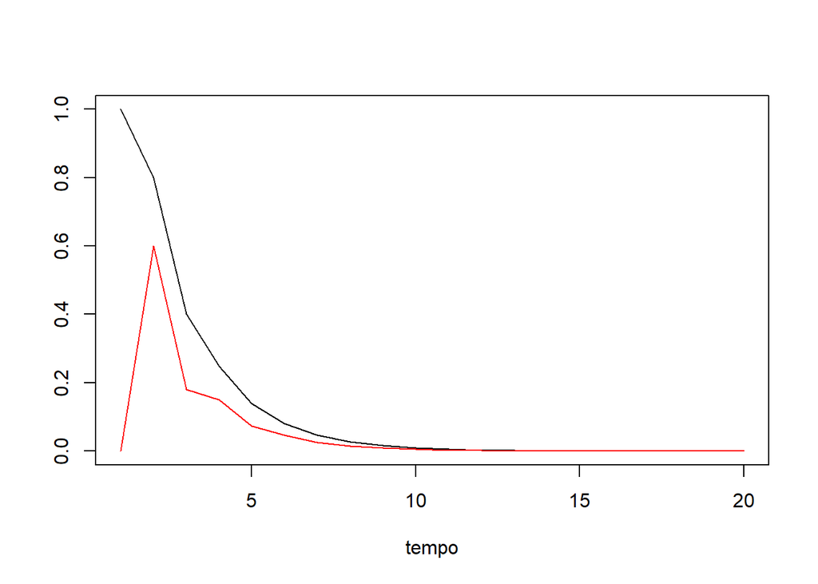

```r
x <- matrix(0,ncol = 2, nrow = 20)
x[1,] <- c(1,0)
for(i in 1:19){
  x[i+1,] <- B%*%x[i,]
}
plot(x[,1], type="l", ylab = " ", xlab = "tempo")
lines(x[,2], type = "l", col = 2)
```

Veja que, nesse caso, o sistema converge para o vetor (0,0). Apesar disso parecer excessivamente rigído, podemos sempre pensar que o vetor $x$ representa desvios do equilíbrio e o equilíbrio é basicamente o que a gente quiser. Talvez um caso mais fascinante é quando nós temos o maior autovalor 1. O autovetor associado vai ser o equilíbrio do sistema. O exemplo abaixo ilustra isso, onde a linha verde representa o equilíbrio:

```r
C = rbind(c(0.8,0.2),c(0.4,0.6))
eigen(C)
```

```
## eigen() decomposition
## $values
## [1] 1.0 0.4
##
## $vectors
##           [,1]       [,2]
## [1,] 0.7071068 -0.4472136
## [2,] 0.7071068  0.8944272
```

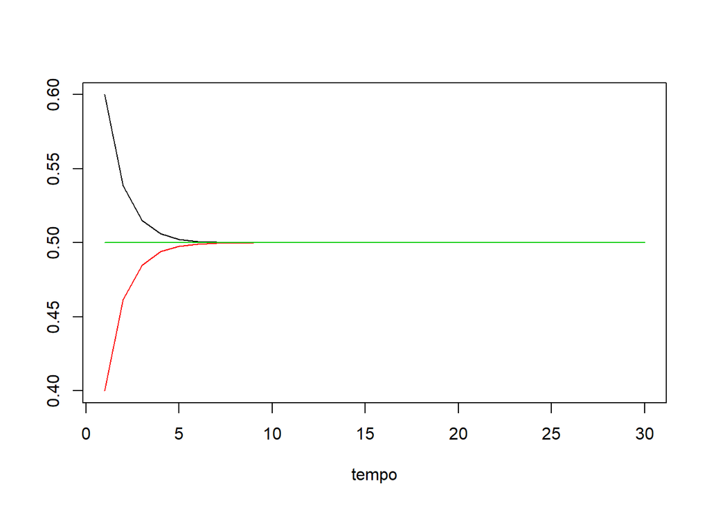

```r
ee <- eigen(C)$vectors[,1]/(eigen(C)$vectors[1,1]+eigen(C)$vectors[2,1])
y <- matrix(0,ncol = 2, nrow = 30)
y[1,] <- c(0.6,0.4)
for(i in 1:29){
  aux <- C%*%y[i,]
  y[i+1,] <- aux/sum(aux)
}
plot(y[,1], type="l", ylab = " ", xlab = "tempo", ylim = c(min(y),max(y)))
lines(y[,2], col = 2)
lines(1:30,rep(ee[1],30), col = 3)
```

Como um autovetor vezes um escalar é também um autovetor, eu escolhi o autovetor que somando os componentes, é igual 1. Isso permite interpretar o autovetor como a probabilidade, em equilíbrio, de cair em qualquer um dos dois estados.